# DS 6372 Project 2

# 7: Predictive Model 4 (Non-Parametric Model)

[output not shown]

```
## Random Forest
##
## 41188 samples
##    19 predictor
##     2 classes: 'no', 'yes'
##
## No pre-processing
## Resampling: Cross-Validated (5 fold, repeated 1 times)
## Summary of sample sizes: 32950, 32951, 32950, 32951, 32950
## Resampling results across tuning parameters:
##
##   mtry  ROC        Sens       Spec
##    2    0.7578264  0.9921747  0.1659483
##   27    0.7721334  0.9672486  0.3066810
##   52    0.7682516  0.9649503  0.3101293
##
## ROC was used to select the optimal model using the largest value.
## The final value used for the model was mtry = 27.
```

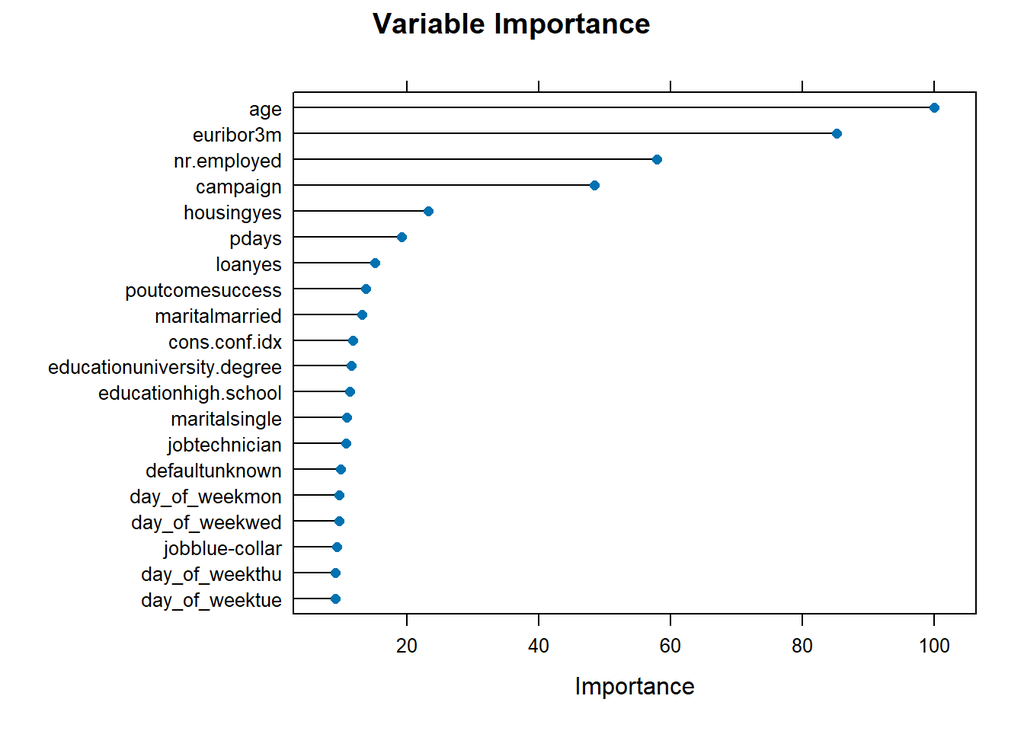

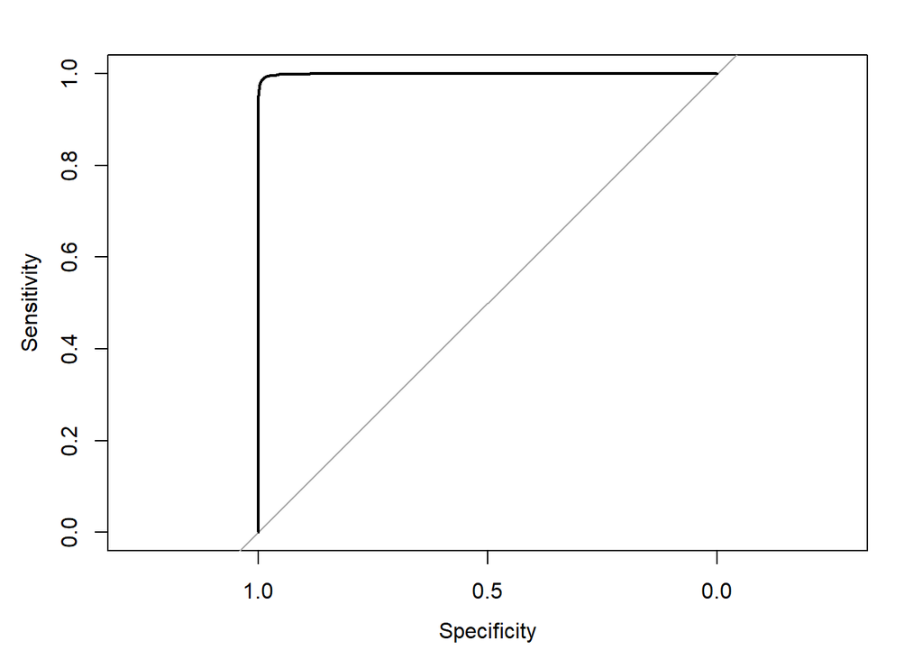

```
##   threshold
## 1     0.285
```

```
## Confusion Matrix and Statistics
##
##           Reference
## Prediction    no   yes
##        no  36118    46
##        yes   430  4594
##
##                Accuracy : 0.9884
##                  95% CI : (0.9874, 0.9895)
##     No Information Rate : 0.8873
##     P-Value [Acc > NIR] : < 2.2e-16
##
##                   Kappa : 0.9442
##
##  Mcnemar's Test P-Value : < 2.2e-16
##
##             Sensitivity : 0.9901
##             Specificity : 0.9882
##          Pos Pred Value : 0.9144
##          Neg Pred Value : 0.9987
##              Prevalence : 0.1127
##          Detection Rate : 0.1115
##    Detection Prevalence : 0.1220
##       Balanced Accuracy : 0.9892
##
##        'Positive' Class : yes
##
```

# 8: Comparative Summary of Predictive Model Performance

## Model Performance Interpretation

In the context of predicting whether a customer will subscribe to a term deposit we consider several key metrics:

- Sensitivity (True Positive Rate): The proportion of actual subscribers correctly identified by the model. High sensitivity means a model would perform better at identifying potential subscribers.
- Specificity (True Negative Rate): The proportion of non-subscribers correctly identified. High specificity in a model would mean we would avoid targeting unlikely customers.
- PPV (Positive Predictive Value): Of all customers predicted to subscribe, what proportion actually did. High PPV would mean that our predictions are reliable when we say “yes.”
- NPV (Negative Predictive Value): Of all customers predicted not to subscribe, the proportion who truly did not. High NPV would show that our model is reliable when saying “no.” Prevalence & AUROC: Prevalence reflects how common it is for customers to subscribe overall (typically low in this dataset), which can affect interpretation of PPV and NPV. AUROC (Area Under the ROC Curve) summarizes how well the model separates subscribers from non-subscribers across all thresholds—a higher AUROC means better overall discrimination.

### Model Performance Priorities

Since a phone marketing campaign has real costs, PPV is crucial: these marketing expenses are best used to target customers who are truly likely to subscribe. However, sensitivity is also important if we don’t want to miss potential customers. Our recommendation would be to choose models that prioritize PPV and sensitivity, with specificity and NPV being less important.

## ROC Curves

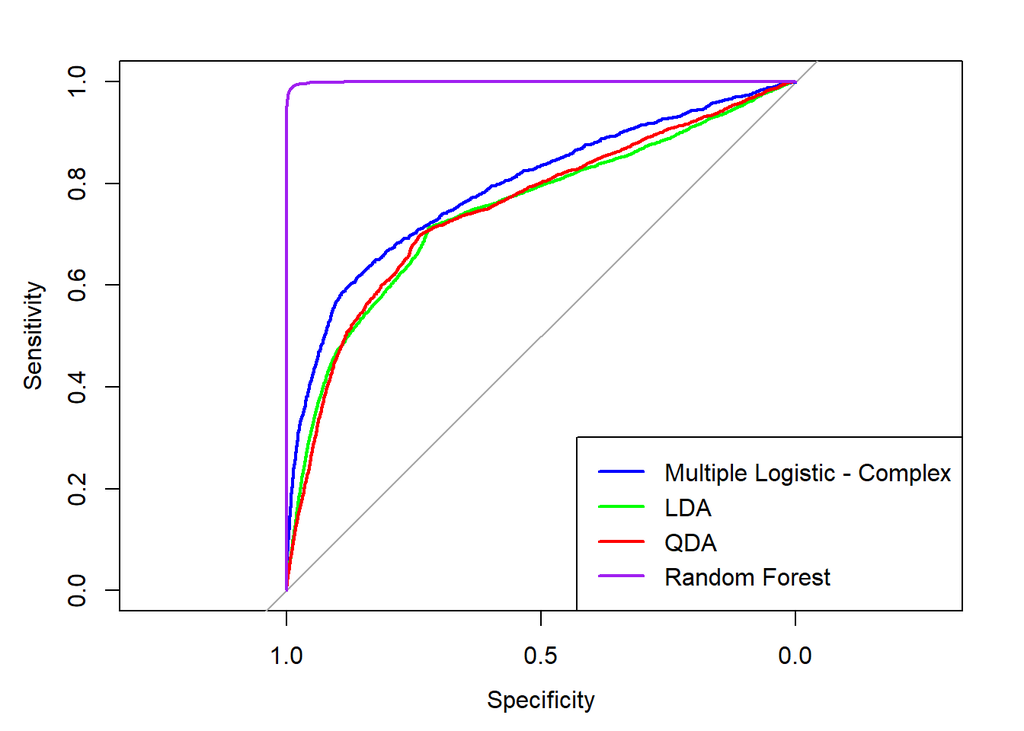

```r
library(pROC)
#plot(roc_obj, col = "blue")
plot(clr_roc_obj, col = "blue", lwd = 2)
lines(lda_roc_obj, col = "green")
lines(qda_roc_obj, col = "red")
lines(rf_roc_obj, col = "purple")

legend("bottomright",
       legend = c("Multiple Logistic - Complex", "LDA", "QDA", "Random Forest"),
       col = c("blue", "green", "red", "purple"),
       lwd = 2)
```

## Summary Table of Comparative Metrics

| Model | Sensitivity | Specificity | PPV | NPV | Prevalence | AUROC |
| --- | --- | --- | --- | --- | --- | --- |
| Interpretive Model | 0.4132 | 0.9704 | 0.6408 | 0.9283 | 0.1132 | 0.9310 |
| Complex Logistic (CLR) | 0.2373 | 0.9856 | 0.6776 | 0.9101 | 0.1132 | 0.7919 |
| LDA | 0.7116 | 0.7210 | 0.2446 | 0.9517 | 0.1127 | 0.7468 |
| QDA | 0.6970 | 0.7394 | 0.2534 | 0.9505 | 0.1127 | 0.7509 |
| Random Forest | 0.9901 | 0.9882 | 0.9144 | 0.9987 | 0.1127 | 0.9993 |

### CLR Metrics

```r
clr_conf = confusionMatrix(as.factor(preds), as.factor(true), positive = "1")

sensitivity = clr_conf$byClass["Sensitivity"]
specificity = clr_conf$byClass["Specificity"]
ppv = clr_conf$byClass["Pos Pred Value"]
npv = clr_conf$byClass["Neg Pred Value"]
prevalence = mean(true)

clr_roc_obj = roc(true, as.numeric(probs))
auroc = auc(clr_roc_obj)

clr_results = list(
  Sensitivity = sensitivity,
  Specificity = specificity,
  PPV = ppv,
  NPV = npv,
  Prevalence = prevalence,
  AUROC = auroc
)
print(clr_results)
```

```
## $Sensitivity
## Sensitivity
##   0.2373124
##
## $Specificity
## Specificity
##   0.9855813
##
## $PPV
## Pos Pred Value
##       0.677551
##
## $NPV
## Neg Pred Value
##      0.9100868
##
## $Prevalence
## [1] 0.1132152
##
## $AUROC
## Area under the curve: 0.7919
```

### LDA Metrics

```r
lda_conf = confusionMatrix(lda_predicted_class, lda_bank_scaled$y, positive = "yes")
lda_sensitivity = lda_conf$byClass["Sensitivity"]
lda_specificity = lda_conf$byClass["Specificity"]
lda_ppv = lda_conf$byClass["Pos Pred Value"]
lda_npv = lda_conf$byClass["Neg Pred Value"]
lda_prevalence = mean(lda_bank_scaled$y == "yes")
lda_auroc = auc(lda_roc_obj)

lda_results = list(
  Sensitivity = lda_sensitivity,
  Specificity = lda_specificity,
  PPV = lda_ppv,
  NPV = lda_npv,
  Prevalence = lda_prevalence,
  AUROC = lda_auroc
)

print(lda_results)
```

```
## $Sensitivity
## Sensitivity
##   0.7116379
##
## $Specificity
## Specificity
##    0.720997
##
## $PPV
## Pos Pred Value
##      0.2446107
##
## $NPV
## Neg Pred Value
##      0.9516776
##
## $Prevalence
## [1] 0.1126542
##
## $AUROC
## Area under the curve: 0.7468
```

### QDA Metrics

```r
qda_conf = confusionMatrix(qda_predicted_class, qda_bank_scaled$y, positive = "yes")
qda_sensitivity = qda_conf$byClass["Sensitivity"]
qda_specificity = qda_conf$byClass["Specificity"]
qda_ppv = qda_conf$byClass["Pos Pred Value"]
qda_npv = qda_conf$byClass["Neg Pred Value"]
qda_prevalence = mean(qda_bank_scaled$y == "yes")
qda_auroc = auc(qda_roc_obj)

qda_results = list(
  Sensitivity = qda_sensitivity,
  Specificity = qda_specificity,
  PPV = qda_ppv,
  NPV = qda_npv,
  Prevalence = qda_prevalence,
  AUROC = qda_auroc
)

print(qda_results)
```

```
## $Sensitivity
## Sensitivity
##   0.6969828
##
## $Specificity
## Specificity
##   0.7393565
##
## $PPV
## Pos Pred Value
##      0.2534483
##
## $NPV
## Neg Pred Value
##      0.9505417
##
## $Prevalence
## [1] 0.1126542
##
## $AUROC
## Area under the curve: 0.7509
```

### Random Forest Metrics

```r
rf_conf = confusionMatrix(rf_predicted_class, rf_bank$y, positive = "yes")
rf_sensitivity = rf_conf$byClass["Sensitivity"]
rf_specificity = rf_conf$byClass["Specificity"]
rf_ppv = rf_conf$byClass["Pos Pred Value"]
rf_npv = rf_conf$byClass["Neg Pred Value"]
rf_prevalence = mean(rf_bank$y == "yes")
rf_auroc = auc(rf_roc_obj)

rf_results = list(
  Sensitivity = rf_sensitivity,
  Specificity = rf_specificity,
  PPV = rf_ppv,
  NPV = rf_npv,
  Prevalence = rf_prevalence,
  AUROC = rf_auroc
)

print(rf_results)
```

```
## $Sensitivity
## Sensitivity
##   0.9900862
##
## $Specificity
## Specificity
##   0.9882347
##
## $PPV
## Pos Pred Value
##      0.9144108
##
## $NPV
## Neg Pred Value
##       0.998728
##
## $Prevalence
## [1] 0.1126542
##
## $AUROC
## Area under the curve: 0.9993
```

# Appendix: Data Sources

Data Source Citation:

[Moro et al., 2011] S. Moro, R. Laureano and P. Cortez. Using Data Mining for Bank Direct Marketing: An Application of the CRISP-DM Methodology. In P. Novais et al. (Eds.), Proceedings of the European Simulation and Modelling Conference - ESM’2011, pp. 117-121, Guimarães, Portugal, October, 2011. EUROSIS.